This practical is based on exploratory data analysis and prediction of a dataset derived from a municipal database of healthcare administrative data. This dataset is derived from Vitoria, the capital city of Espírito Santo, Brazil (population 1.8 million) and was freely shared under a creative commons license.

**Generate an rmarkdown report that contains all the necessary code to document and perform: EDA, prediction of no-shows using XGBoost, and an analysis of variable/feature importance using this data set. Ensure your report includes answers to any questions marked in bold. Please submit your report via brightspace as a link to a git repository containing the rmarkdown and compiled/knitted html version of the notebook.**

## Introduction

The Brazilian public health system, known as SUS for Unified Health System in its acronym in Portuguese, is one of the largest health system in the world, representing government investment of more than 9% of GDP. However, its operation is not homogeneous and there are distinct perceptions of quality from citizens in different regions of the country. Non-attendance of medical appointments contributes a significant additional burden on limited medical resources. This analysis will try and investigate possible factors behind non-attendance using an administrative database of appointment data from Vitoria, Espírito Santo, Brazil.

The data required is available via the [course website](https://github.com/maguire-lab/health_data_science_research_2025/tree/master/static_files/practicals/lab1_data).

### Understanding the data

**1** Use the data dictionary describe each of the variables/features in the CSV in your report.

# Data Dictionary

#PatientID: Unique identifier for each patient #AppointmentID: Unique identifier to each appointment #Gender: Patient Gender (limited to Male or Female) #ScheduledDate: date on which the appointment was scheduled #AppointmentDate: date of the actual appointment #Age: Patient age #Neighbourhood: District of Vitória in which the appointment #SocialWelfare: Patient is a recipient of Bolsa Família welfare payments #Hypertension: Patient previously diagnoised with hypertensio (Boolean) #Diabetes: Patient previously diagnosed with diabetes (Boolean) #AlcoholUseDisorder: Patient previously diagnosed with alcohol use disorder (Boolean) #Disability: Patient previously diagnosed with a disability (severity rated 0-4) #SMSReceived: At least 1 reminder text sent before appointment (Boolean) #NoShow: Patient did not attend scheduled appointment (Boolean: Yes/No)

**2** Can you think of 3 hypotheses for why someone may be more likely to miss a medical appointment?

#1- Missing sms reminder messages. #2- Miscalculating the trip’s duration #3- Emergency priorotizing varies between children and adults, where children are careless and more likely to miss an appointment.

**3** Can you provide 3 examples of important contextual information that is missing in this data dictionary and dataset that could impact your analyses e.g., what type of medical appointment does each `AppointmentID` refer to?

#1- Distance from each neighborhood #2- Weather on the appointment day #3- How long before the appointment the SMS reminder was sent

## Data Parsing and Cleaning

**4** Modify the following to make it reproducible i.e., downloads the data file directly from version control

```r
raw.data <- read_csv('2016_05v2_VitoriaAppointmentData.csv',col_types='fffTTifllllflf')
#raw.data <- readr::read_csv('https://raw.githubusercontent.com/maguire-lab/health_data_science_research_2025/ ... ')
```

Now we need to check data is valid: because we specified col_types and the data parsed without error most of our data seems to at least be formatted as we expect i.e., ages are integers

```r
raw.data %>% filter(Age > 110)
```

```
## # A tibble: 5 × 14
##   PatientID   AppointmentID Gender ScheduledDate       AppointmentDate       Age
##   <fct>       <fct>         <fct>  <dttm>              <dttm>              <int>
## 1 3196321161… 5700278       F      2016-05-16 09:17:44 2016-05-19 00:00:00   115
## 2 3196321161… 5700279       F      2016-05-16 09:17:44 2016-05-19 00:00:00   115
## 3 3196321161… 5562812       F      2016-04-08 14:29:17 2016-05-16 00:00:00   115
## 4 3196321161… 5744037       F      2016-05-30 09:44:51 2016-05-30 00:00:00   115
## 5 7482345792… 5717451       F      2016-05-19 07:57:56 2016-06-03 00:00:00   115
## # ℹ 8 more variables: Neighbourhood <fct>, SocialWelfare <lgl>,
## #   Hypertension <lgl>, Diabetes <lgl>, AlcoholUseDisorder <lgl>,
## #   Disability <fct>, SMSReceived <lgl>, NoShow <fct>
```

We can see there are 2 patient’s older than 110 which seems suspicious but we can’t actually say if this is impossible.

**5** Are there any individuals with impossible ages? If so we can drop this row using `filter` i.e., `data <- data %>% filter(CRITERIA)` #chekig impossible ages (below 0 and above 110)

```r
raw.data %>% filter(Age< 0 | Age > 110)
```

```
## # A tibble: 6 × 14
##   PatientID   AppointmentID Gender ScheduledDate       AppointmentDate       Age
##   <fct>       <fct>         <fct>  <dttm>              <dttm>              <int>
## 1 3196321161… 5700278       F      2016-05-16 09:17:44 2016-05-19 00:00:00   115
## 2 3196321161… 5700279       F      2016-05-16 09:17:44 2016-05-19 00:00:00   115
## 3 3196321161… 5562812       F      2016-04-08 14:29:17 2016-05-16 00:00:00   115
## 4 3196321161… 5744037       F      2016-05-30 09:44:51 2016-05-30 00:00:00   115
## 5 7482345792… 5717451       F      2016-05-19 07:57:56 2016-06-03 00:00:00   115
## 6 4659431587… 5775010       F      2016-06-06 08:58:13 2016-06-06 00:00:00    -1
## # ℹ 8 more variables: Neighbourhood <fct>, SocialWelfare <lgl>,
## #   Hypertension <lgl>, Diabetes <lgl>, AlcoholUseDisorder <lgl>,
## #   Disability <fct>, SMSReceived <lgl>, NoShow <fct>
```

#dropping 6 rows, 5 above 110 (115yrs old) and 1 below 0(-1)

```r
raw.data <- raw.data %>% filter(Age >=0 & Age <=110)
```

#making sure patients with the age 0 are still there

```r
raw.data %>% filter(Age== 0)
```

```
## # A tibble: 3,539 × 14
##    PatientID  AppointmentID Gender ScheduledDate       AppointmentDate       Age
##    <fct>      <fct>         <fct>  <dttm>              <dttm>              <int>
##  1 718442847… 5638545       F      2016-04-29 08:08:43 2016-04-29 00:00:00     0
##  2 236623344… 5628286       M      2016-04-27 10:46:12 2016-04-29 00:00:00     0
##  3 188517384… 5616082       M      2016-04-25 13:28:21 2016-04-29 00:00:00     0
##  4 271881817… 5628321       M      2016-04-27 10:48:50 2016-04-29 00:00:00     0
##  5 864712825… 5639264       F      2016-04-29 08:53:02 2016-04-29 00:00:00     0
##  6 431493164… 5640380       M      2016-04-29 10:37:02 2016-04-29 00:00:00     0
##  7 682284733… 5642813       M      2016-04-29 17:24:19 2016-04-29 00:00:00     0
##  8 332698521… 5632495       F      2016-04-28 08:04:48 2016-04-29 00:00:00     0
##  9 846858655… 5560742       M      2016-04-08 09:29:23 2016-04-29 00:00:00     0
## 10 539241872… 5641476       M      2016-04-29 13:43:34 2016-04-29 00:00:00     0
## # ℹ 3,529 more rows
## # ℹ 8 more variables: Neighbourhood <fct>, SocialWelfare <lgl>,
## #   Hypertension <lgl>, Diabetes <lgl>, AlcoholUseDisorder <lgl>,
## #   Disability <fct>, SMSReceived <lgl>, NoShow <fct>
```

## Exploratory Data Analysis

First, we should get an idea if the data meets our expectations, there are newborns in the data (`Age==0`) and we wouldn’t expect any of these to be diagnosed with Diabetes, Alcohol Use Disorder, and Hypertension (although in theory it could be possible). We can easily check this:

```r
raw.data %>% filter(Age == 0) %>% select(Hypertension, Diabetes, AlcoholUseDisorder) %>% unique()
```

```
## # A tibble: 1 × 3
##   Hypertension Diabetes AlcoholUseDisorder
##   <lgl>        <lgl>    <lgl>
## 1 FALSE        FALSE    FALSE
```

We can also explore things like how many different neighborhoods are there and how many appoints are from each?

```r
count(raw.data, Neighbourhood, sort = TRUE)
```

```
## # A tibble: 81 × 2
##    Neighbourhood         n
##    <fct>             <int>
##  1 JARDIM CAMBURI     7717
##  2 MARIA ORTIZ        5805
##  3 RESISTÊNCIA        4431
##  4 JARDIM DA PENHA    3877
##  5 ITARARÉ            3514
##  6 CENTRO             3334
##  7 TABUAZEIRO         3132
##  8 SANTA MARTHA       3131
##  9 JESUS DE NAZARETH  2853
## 10 BONFIM             2773
## # ℹ 71 more rows
```

**6** What is the maximum number of appointments from the same patient?

```r
count(raw.data, PatientID, sort = TRUE) %>% head(1)
```

```
## # A tibble: 1 × 2
##   PatientID           n
##   <fct>           <int>
## 1 822145925426128    88
```

# the maximum appoinments number from the same patient is 88.

Let’s explore the correlation between variables:

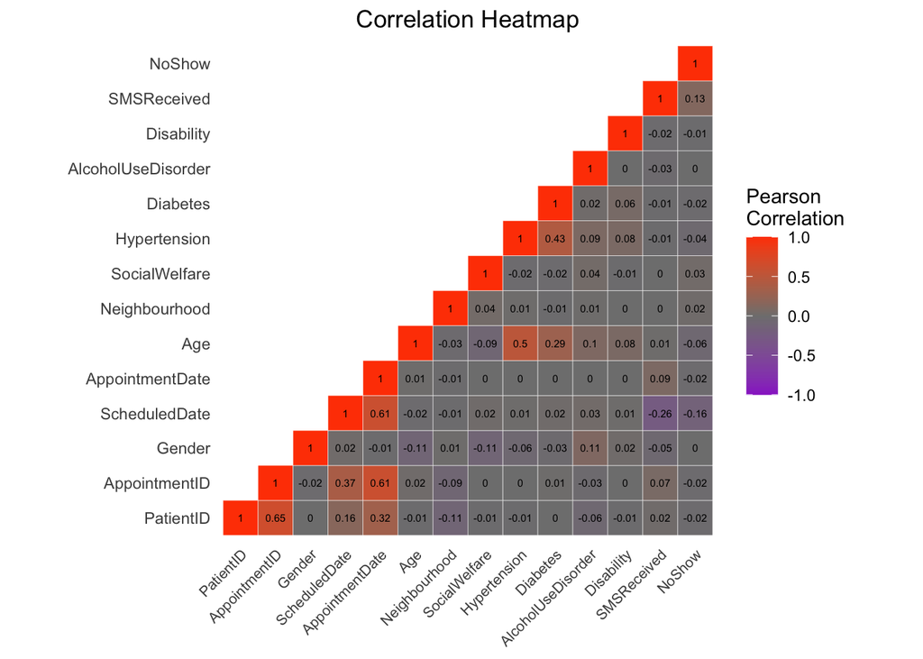

```r
# let's define a plotting function
corplot = function(df){

  cor_matrix_raw <- round(cor(df),2)
  cor_matrix <- melt(cor_matrix_raw)


  #Get triangle of the correlation matrix
  #Lower Triangle
  get_lower_tri<-function(cor_matrix_raw){
    cor_matrix_raw[upper.tri(cor_matrix_raw)] <- NA
    return(cor_matrix_raw)
  }

  # Upper Triangle
  get_upper_tri <- function(cor_matrix_raw){
    cor_matrix_raw[lower.tri(cor_matrix_raw)]<- NA
    return(cor_matrix_raw)
  }

  upper_tri <- get_upper_tri(cor_matrix_raw)

  # Melt the correlation matrix
  cor_matrix <- melt(upper_tri, na.rm = TRUE)

  # Heatmap Plot
  cor_graph <- ggplot(data = cor_matrix, aes(Var2, Var1, fill = value))+
    geom_tile(color = "white")+
    scale_fill_gradient2(low = "darkorchid", high = "orangered", mid = "grey50",
                         midpoint = 0, limit = c(-1,1), space = "Lab",
                         name="Pearson\nCorrelation") +
    theme_minimal()+
    theme(axis.text.x = element_text(angle = 45, vjust = 1,
                                     size = 8, hjust = 1))+
    coord_fixed()+ geom_text(aes(Var2, Var1, label = value), color = "black", size = 2) +
    theme(
      axis.title.x = element_blank(),
      axis.title.y = element_blank(),
      panel.grid.major = element_blank(),
      panel.border = element_blank(),
      panel.background = element_blank(),
      axis.ticks = element_blank())+
      ggtitle("Correlation Heatmap")+
      theme(plot.title = element_text(hjust = 0.5))

  cor_graph
}

numeric.data = mutate_all(raw.data, function(x) as.numeric(x))

# Plot Correlation Heatmap
corplot(numeric.data)
```

Correlation heatmaps are useful for identifying linear relationships between variables/features. In this case, we are particularly interested in relationships between `NoShow` and any specific variables.

**7** Which parameters most strongly correlate with missing appointments (`NoShow`)?

# showing parameter that has more than 0.1 correlation with (NoShow)

```r
round(cor(numeric.data)[cor(numeric.data) [ ,"NoShow"] > 0.1,"NoShow"] ,2)
```

```
## SMSReceived      NoShow
##        0.13        1.00
```

#SMSRecieved(0.13) and itself(1.00)

**8** Are there any other variables which strongly correlate with one another?

# displaying parameter that has more that 0.5 correlation with one another

```r
cm_raw <- round(cor(numeric.data), 2)
get_upper_tri <- function(m) { m[lower.tri(m)] <- NA; m }

melt(get_upper_tri(cm_raw), na.rm = TRUE) %>%
  filter(value > 0.5, Var1 != Var2)
```

```
##            Var1            Var2 value
## 1     PatientID   AppointmentID  0.65
## 2 AppointmentID AppointmentDate  0.61
## 3 ScheduledDate AppointmentDate  0.61
```

#PatientID and AppointmentID(0.65), AppointmentID and AppointmentDate(0.61), ScheduledDate and AppointmentDate (0.61)

**9** Do you see any issues with PatientID/AppointmentID being included in this plot?

#Yes, they are both useless in this relationships chars, it doesnt have any effect.

Let’s look at some individual variables and their relationship with `NoShow`.

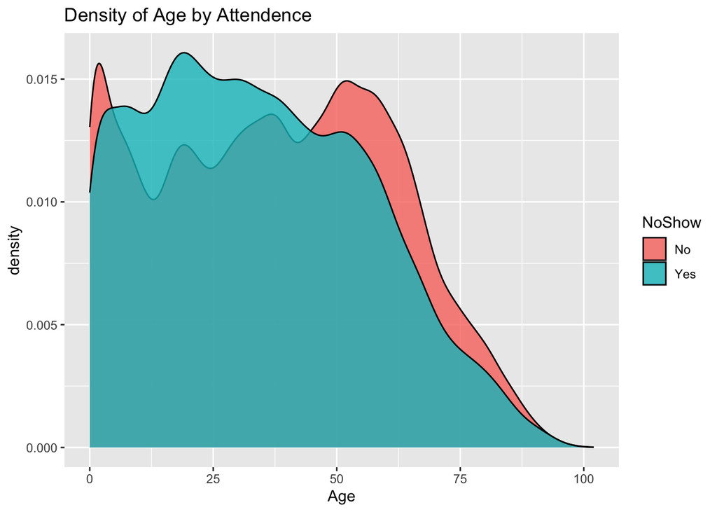

```r
ggplot(raw.data) +
  geom_density(aes(x=Age, fill=NoShow), alpha=0.8) +
  ggtitle("Density of Age by Attendence")
```

There does seem to be a difference in the distribution of ages of people that miss and don’t miss appointments.  
However, the shape of this distribution means the actual correlation is near 0 in the heatmap above. This highlights the need to look at individual variables.

Let’s take a closer look at age by breaking it into categories.

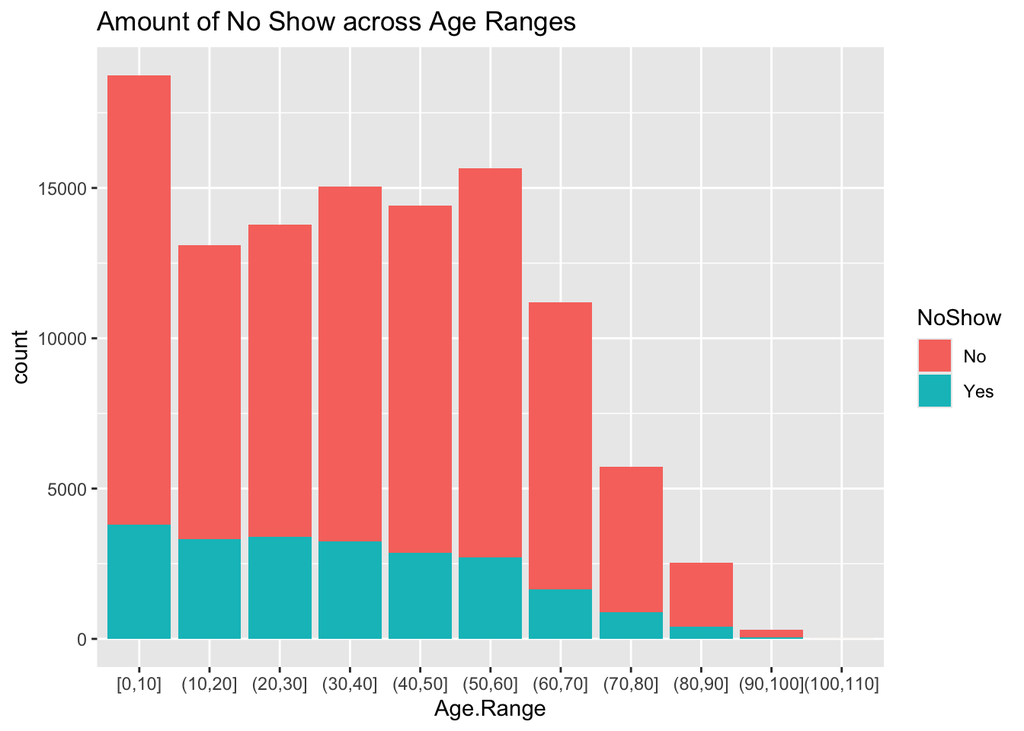

```r
raw.data <- raw.data %>% mutate(Age.Range=cut_interval(Age, length=10))

ggplot(raw.data) +
  geom_bar(aes(x=Age.Range, fill=NoShow)) +
  ggtitle("Amount of No Show across Age Ranges")
```

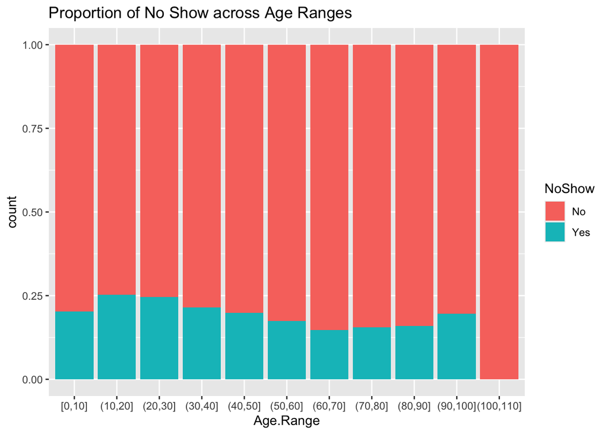

```r
ggplot(raw.data) +
  geom_bar(aes(x=Age.Range, fill=NoShow), position='fill') +
  ggtitle("Proportion of No Show across Age Ranges")
```

**10** How could you be misled if you only plotted 1 of these 2 plots of attendance by age group?

#bcause the first chart shows the count where some age groups have higher appointments which will show as a peak, where the on the other hand, it shows the proportion shows small bars for old ages which might mislead for a higher (no show) when in fact this group is small.

The key takeaway from this is that number of individuals > 90 are very few from plot 1 so probably are very small so unlikely to make much of an impact on the overall distributions. However, other patterns do emerge such as 10-20 age group is nearly twice as likely to miss appointments as the 60-70 years old.

Next, we’ll have a look at `SMSReceived` variable:

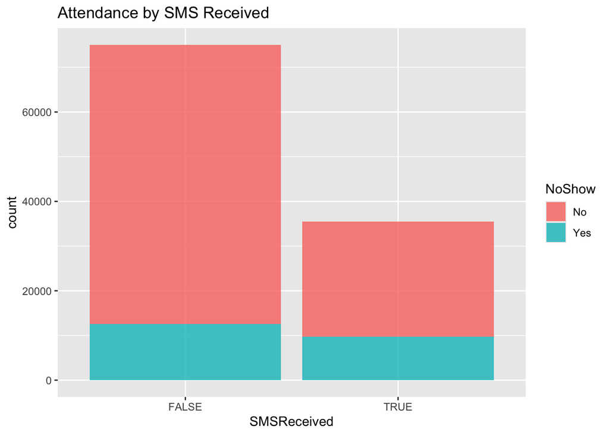

```r
ggplot(raw.data) +
  geom_bar(aes(x=SMSReceived, fill=NoShow), alpha=0.8) +
  ggtitle("Attendance by SMS Received")
```

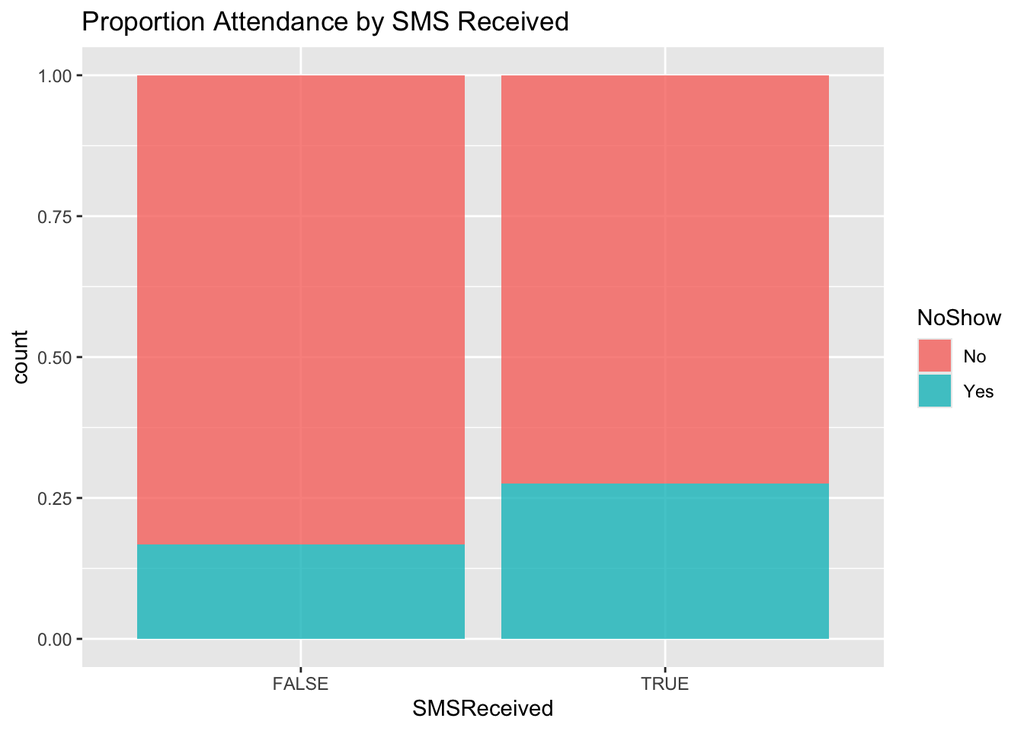

```r
ggplot(raw.data) +
  geom_bar(aes(x=SMSReceived, fill=NoShow), position='fill', alpha=0.8) +
  ggtitle("Proportion Attendance by SMS Received")
```

**11** From this plot does it look like SMS reminders increase or decrease the chance of someone not attending an appointment? Why might the opposite actually be true (hint: think about biases)?

#The plot shows that the sms reminder decreases the show ups, because the text might be a 15 minutes reminder before the appointment when the patient hasnt already showed up (and wasnt going to), so the SMS remminders are basically for the one who didnt show up.

**12** Create a similar plot which compares the the density of `NoShow` across the values of disability

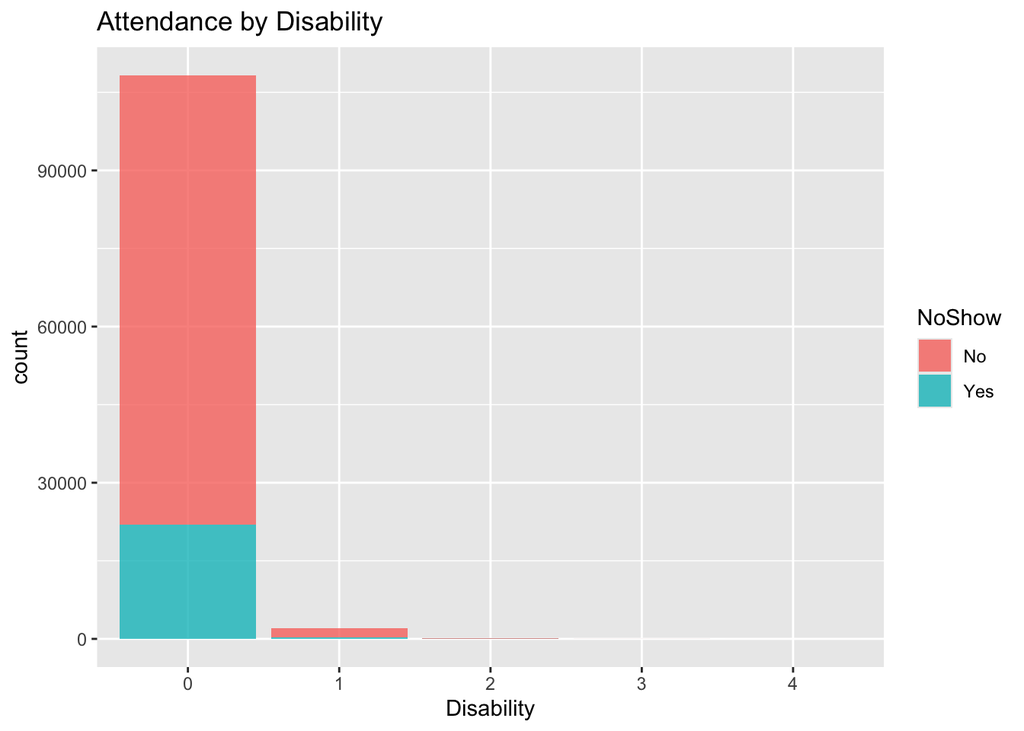

```r
ggplot(raw.data) +
  geom_bar(aes(x=Disability, fill=NoShow), alpha=0.8) +
  ggtitle("Attendance by Disability")
```

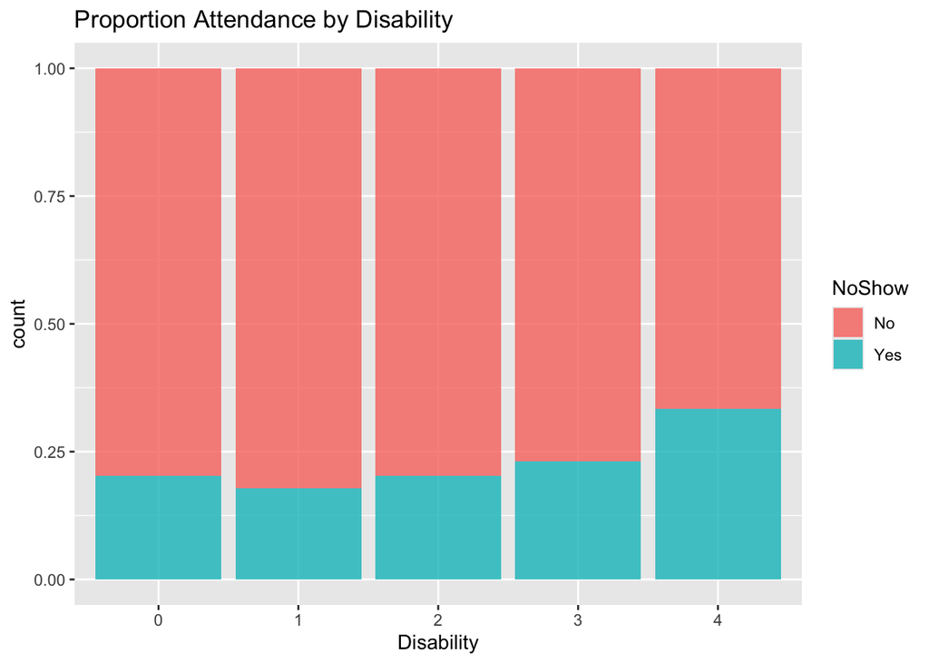

```r
ggplot(raw.data) +
  geom_bar(aes(x=Disability, fill=NoShow), position='fill', alpha=0.8) +
  ggtitle("Proportion Attendance by Disability")
```

Now let’s look at the neighbourhood data as location can correlate highly with many social determinants of health.

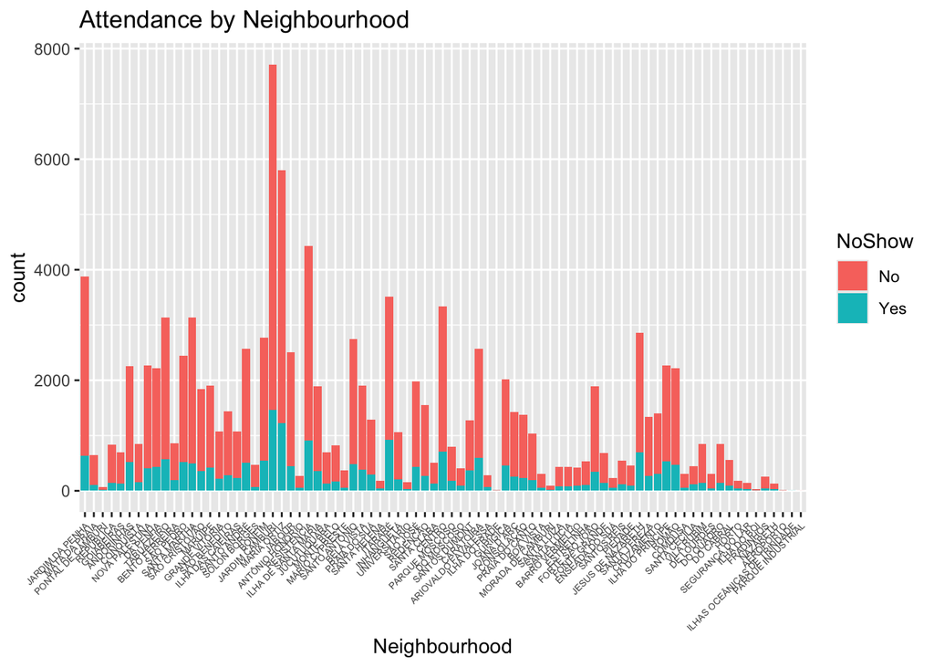

```r
ggplot(raw.data) +
  geom_bar(aes(x=Neighbourhood, fill=NoShow)) +
  theme(axis.text.x = element_text(angle=45, hjust=1, size=5)) +
  ggtitle('Attendance by Neighbourhood')
```

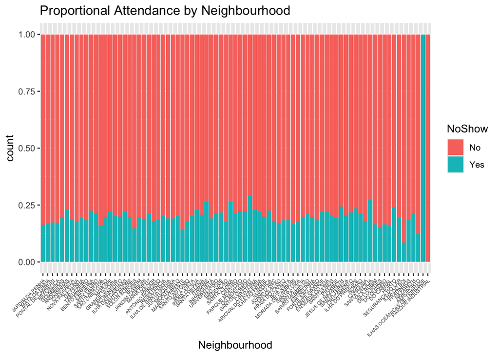

```r
ggplot(raw.data) +
  geom_bar(aes(x=Neighbourhood, fill=NoShow), position='fill') +
  theme(axis.text.x = element_text(angle=45, hjust=1, size=5)) +
  ggtitle('Proportional Attendance by Neighbourhood')
```

Most neighborhoods have similar proportions of no-show but some have much higher and lower rates.

**13** Suggest a reason for differences in attendance rates across neighbourhoods.

#Traffic, road constructions, distanse and transportiation might affect the attendance rates.

Now let’s explore the relationship between gender and NoShow.

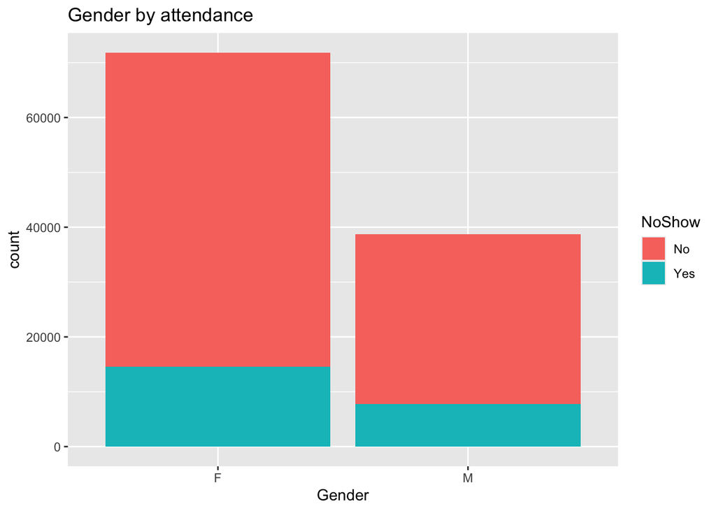

```r
ggplot(raw.data) +
  geom_bar(aes(x=Gender, fill=NoShow))+
  ggtitle("Gender by attendance")
```

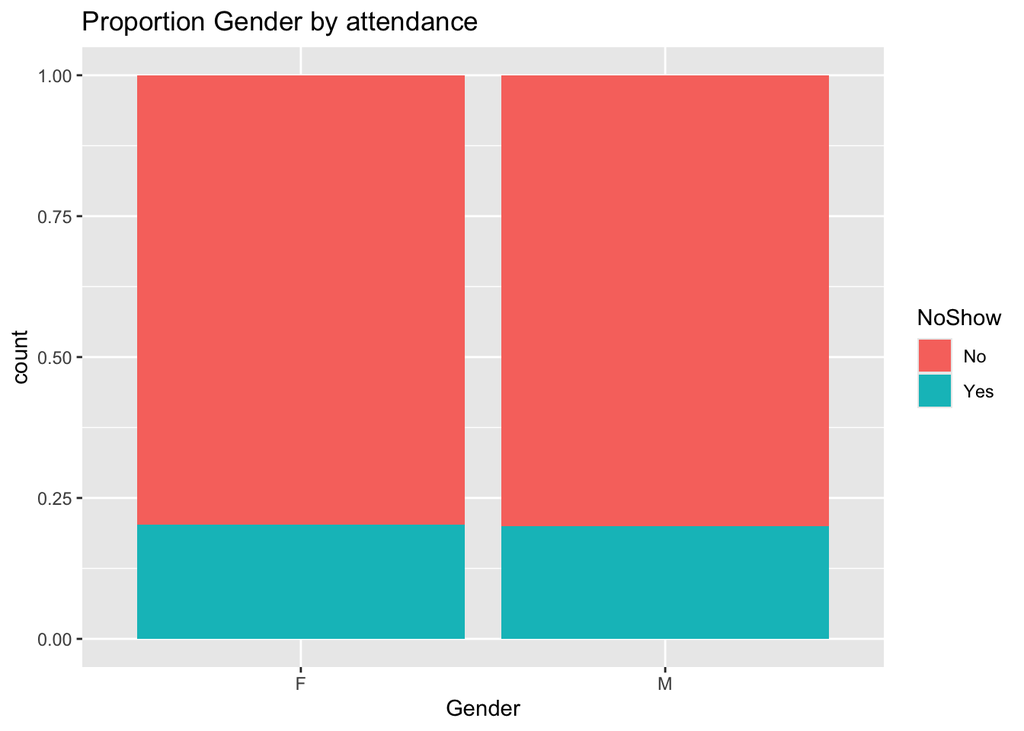

```r
ggplot(raw.data) +
  geom_bar(aes(x=Gender, fill=NoShow), position='fill')+
  ggtitle("Proportion Gender by attendance")
```

**14** Create a similar plot using `SocialWelfare`

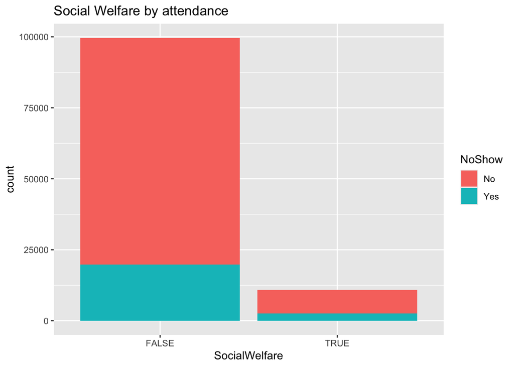

```r
ggplot(raw.data) +
  geom_bar(aes(x=SocialWelfare, fill=NoShow))+
  ggtitle("Social Welfare by attendance")
```

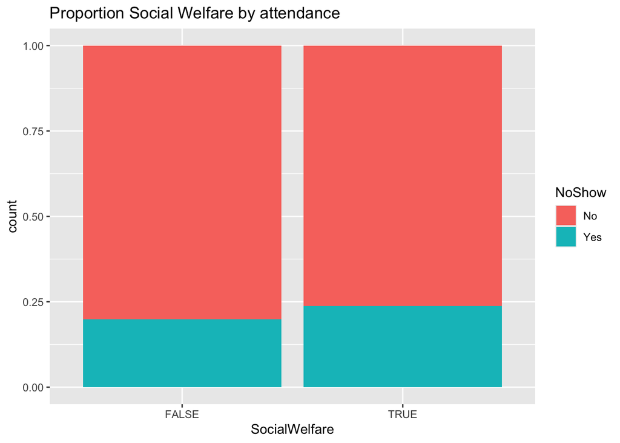

```r
ggplot(raw.data) +
  geom_bar(aes(x=SocialWelfare, fill=NoShow), position='fill')+
  ggtitle("Proportion Social Welfare by attendance")
```

Far more exploration could still be done, including dimensionality reduction approaches but although we have found some patterns there is no major/striking patterns on the data as it currently stands.

However, maybe we can generate some new features/variables that more strongly relate to the `NoShow`.

## Feature Engineering

Let’s begin by seeing if appointments on any day of the week has more no-show’s. Fortunately, the `lubridate` library makes this quite easy!

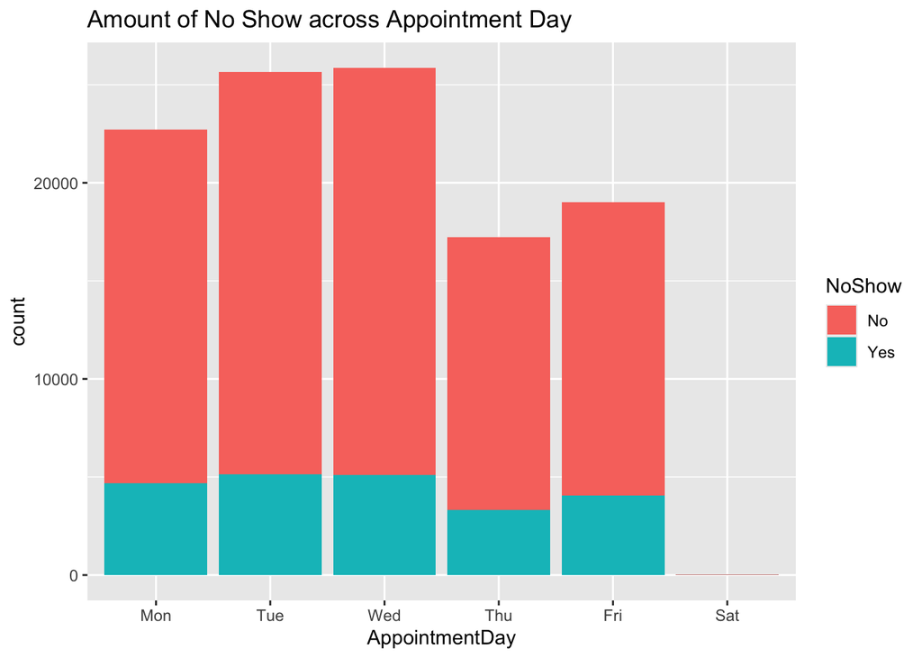

```r
raw.data <- raw.data %>% mutate(AppointmentDay = wday(AppointmentDate, label=TRUE, abbr=TRUE),
                                 ScheduledDay = wday(ScheduledDate,  label=TRUE, abbr=TRUE))

ggplot(raw.data) +
  geom_bar(aes(x=AppointmentDay, fill=NoShow)) +
  ggtitle("Amount of No Show across Appointment Day")
```

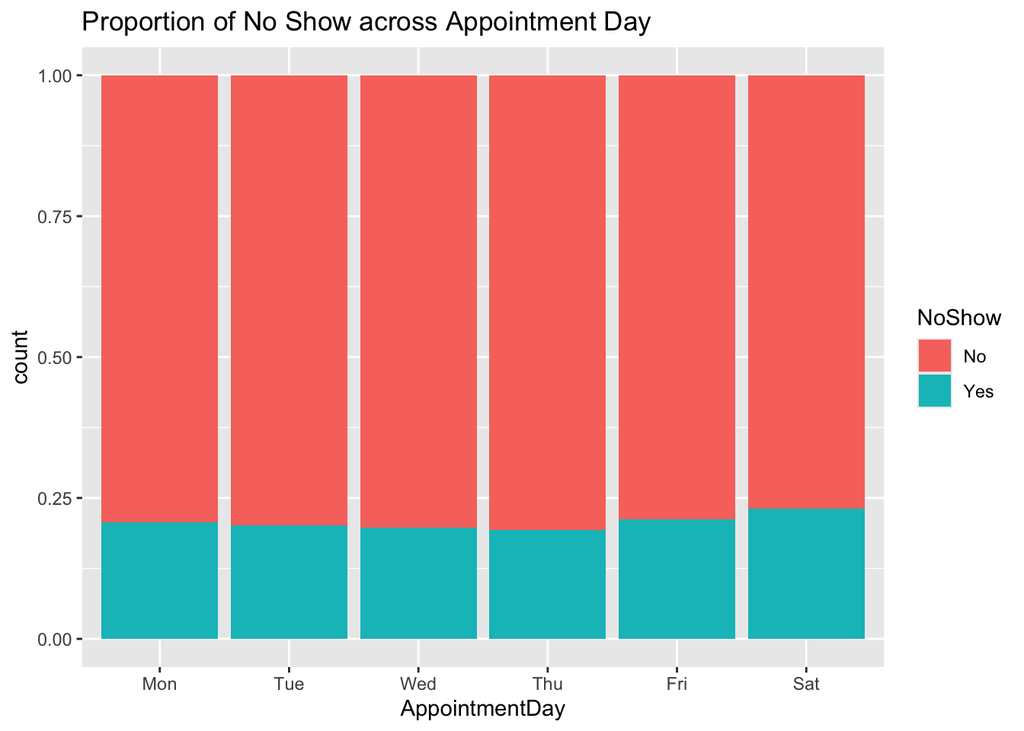

```r
ggplot(raw.data) +
  geom_bar(aes(x=AppointmentDay, fill=NoShow), position = 'fill') +
  ggtitle("Proportion of No Show across Appointment Day")
```

Let’s begin by creating a variable called `Lag`, which is the difference between when an appointment was scheduled and the actual appointment.

```
## Defaulting to continuous.
```

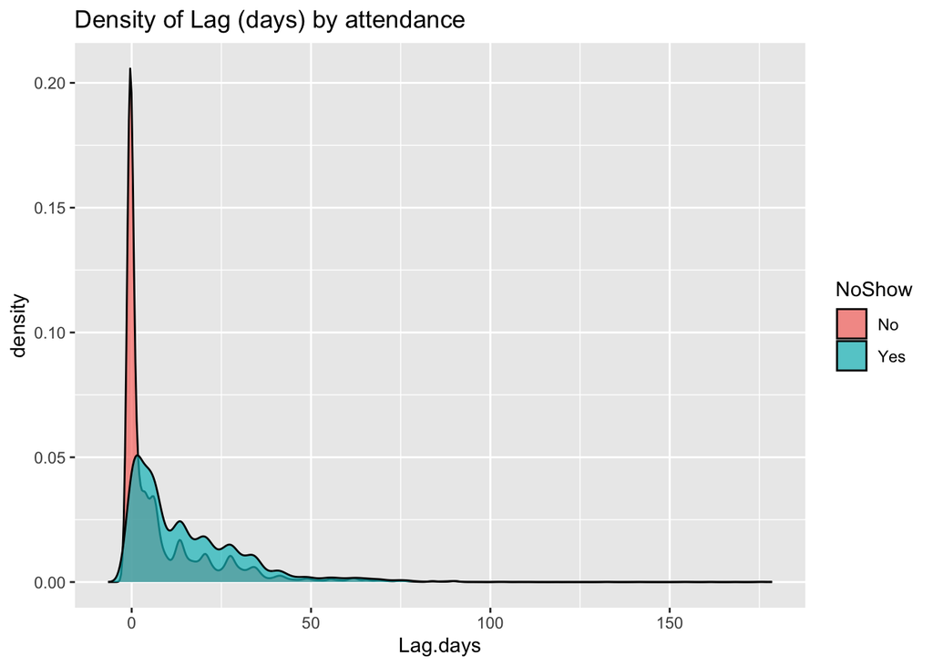

```r
raw.data <- raw.data %>% mutate(Lag.days=difftime(AppointmentDate, ScheduledDate, units = "days"),
                                Lag.hours=difftime(AppointmentDate, ScheduledDate, units = "hours"))

ggplot(raw.data) +
  geom_density(aes(x=Lag.days, fill=NoShow), alpha=0.7)+
  ggtitle("Density of Lag (days) by attendance")
```

**15** Have a look at the values in lag variable, does anything seem odd?

#Yes, its peak was a negative number and zero, and the density reached 0 at day 50 and lasted more than a 100 days.

## Predictive Modeling

Let’s see how well we can predict NoShow from the data.

We’ll start by preparing the data, followed by splitting it into testing and training set, modeling and finally, evaluating our results. For now we will subsample but please run on full dataset for final execution.

```r
### REMOVE SUBSAMPLING FOR FINAL MODEL
data.prep <- raw.data %>% select(-AppointmentID, -PatientID) #%>% sample_n(10000)

set.seed(42)
data.split <- initial_split(data.prep, prop = 0.7)
train  <- training(data.split)
test <- testing(data.split)
```

Let’s now set the cross validation parameters, and add classProbs so we can use AUC as a metric for xgboost.

```r
fit.control <- trainControl(method="cv",number=3,
                           classProbs = TRUE, summaryFunction = twoClassSummary)
```

**16** Based on the EDA, how well do you think this is going to work?

#Based on the data analysis, there were weak data to base on anything, there were hardly any connections with (no show) except for a few whcih is not worth the EDA.

Now we can train our XGBoost model

```r
xgb.grid <- expand.grid(eta=c(0.05),
                       max_depth=c(4),colsample_bytree=1,
                       subsample=1, nrounds=500, gamma=0, min_child_weight=5)

xgb.model <- train(NoShow ~ .,data=train, method="xgbTree",metric="ROC",
                  tuneGrid=xgb.grid, trControl=fit.control)

xgb.pred <- predict(xgb.model, newdata=test)
xgb.probs <- predict(xgb.model, newdata=test, type="prob")
```

```r
test <- test %>% mutate(NoShow.numerical = ifelse(NoShow=="Yes",1,0))
confusionMatrix(xgb.pred, test$NoShow, positive="Yes")
```

```
## Confusion Matrix and Statistics
##
##           Reference
## Prediction    No   Yes
##        No  26334  6488
##        Yes   130   205
##
##                Accuracy : 0.8004
##                  95% CI : (0.7961, 0.8047)
##     No Information Rate : 0.7981
##     P-Value [Acc > NIR] : 0.154
##
##                   Kappa : 0.0399
##
##  Mcnemar's Test P-Value : <2e-16
##
##             Sensitivity : 0.030629
##             Specificity : 0.995088
##          Pos Pred Value : 0.611940
##          Neg Pred Value : 0.802328
##              Prevalence : 0.201858
##          Detection Rate : 0.006183
##    Detection Prevalence : 0.010103
##       Balanced Accuracy : 0.512858
##
##        'Positive' Class : Yes
##
```

```r
paste("XGBoost Area under ROC Curve: ", round(auc(test$NoShow.numerical, xgb.probs[,2]),3), sep="")
```

```
## [1] "XGBoost Area under ROC Curve: 0.743"
```

This isn’t an unreasonable performance, but let’s look a bit more carefully at the correct and incorrect predictions,

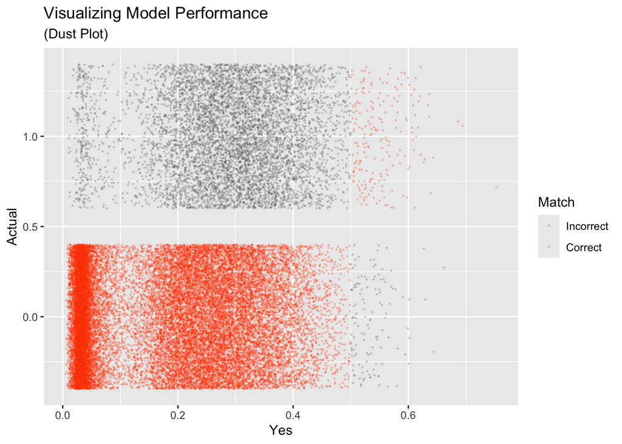

```r
xgb.probs$Actual = test$NoShow.numerical
xgb.probs$ActualClass = test$NoShow
xgb.probs$PredictedClass = xgb.pred
xgb.probs$Match = ifelse(xgb.probs$ActualClass == xgb.probs$PredictedClass,
                         "Correct","Incorrect")
# [4.8] Plot Accuracy
xgb.probs$Match = factor(xgb.probs$Match,levels=c("Incorrect","Correct"))
ggplot(xgb.probs,aes(x=Yes,y=Actual,color=Match))+
  geom_jitter(alpha=0.2,size=0.25)+
  scale_color_manual(values=c("grey40","orangered"))+
  ggtitle("Visualizing Model Performance", "(Dust Plot)")
```

Finally, let’s close it off with the variable importance of our model:

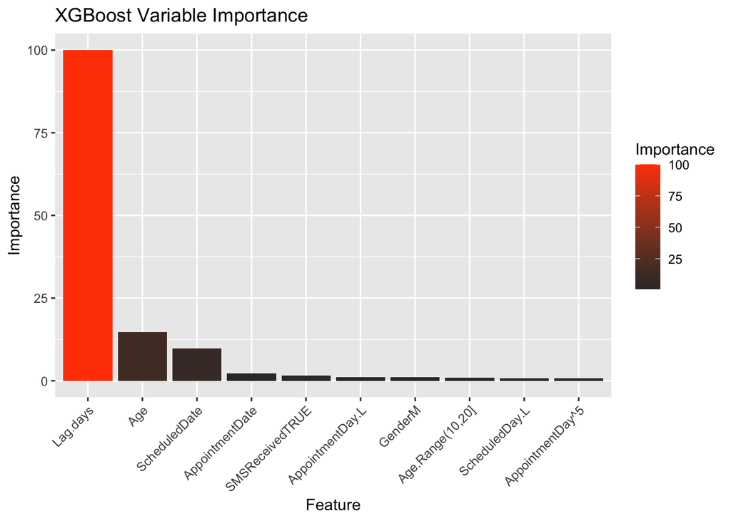

```r
results = data.frame(Feature = rownames(varImp(xgb.model)$importance)[1:10],
                     Importance = varImp(xgb.model)$importance[1:10,])

results$Feature = factor(results$Feature,levels=results$Feature)


# [4.10] Plot Variable Importance
ggplot(results, aes(x=Feature, y=Importance,fill=Importance))+
  geom_bar(stat="identity")+
  scale_fill_gradient(low="grey20",high="orangered")+
  ggtitle("XGBoost Variable Importance")+
  theme(axis.text.x = element_text(angle = 45, hjust = 1))
```

**17** Using the [caret package](https://topepo.github.io/caret/) fit and evaluate 1 other ML model on this data.

#training lgm (logestic regression)

```r
glm.model <- train(NoShow ~ .,data=train, method="glm", family = "binomial", metric="ROC", trControl=fit.control)

glm.pred <- predict(glm.model, newdata=test)
glm.probs <- predict(glm.model, newdata=test, type="prob")

confusionMatrix(glm.pred, test$NoShow, positive="Yes")
```

```
## Confusion Matrix and Statistics
##
##           Reference
## Prediction    No   Yes
##        No  26232  6574
##        Yes   232   119
##
##                Accuracy : 0.7947
##                  95% CI : (0.7903, 0.7991)
##     No Information Rate : 0.7981
##     P-Value [Acc > NIR] : 0.9396
##
##                   Kappa : 0.014
##
##  Mcnemar's Test P-Value : <2e-16
##
##             Sensitivity : 0.017780
##             Specificity : 0.991233
##          Pos Pred Value : 0.339031
##          Neg Pred Value : 0.799610
##              Prevalence : 0.201858
##          Detection Rate : 0.003589
##    Detection Prevalence : 0.010586
##       Balanced Accuracy : 0.504507
##
##        'Positive' Class : Yes
##
```

```r
paste("GLM AUC:", round(auc(test$NoShow.numerical, glm.probs$Yes), 3))
```

```
## [1] "GLM AUC: 0.667"
```

**18** Based on everything, do you think we can trust analyses based on this dataset? Explain your reasoning.

## Credits

This notebook was based on a combination of other notebooks e.g., [1](https://www.kaggle.com/code/tsilveira/applying-heatmaps-for-categorical-data-analysis), [2](https://www.kaggle.com/code/samratp/predict-show-noshow-eda-visualization-model), [3](https://www.kaggle.com/code/andrewmvd/exploring-and-predicting-no-shows-with-xgboost/report)